# Examining the relationship between the big-5 personality facets and implicit racial attitudes

Data analysis

Template: Laura Hirt; content: Laura Hirt

2023-12-19

# Dependencies

```r
library(tidyverse)
library(knitr)
library(kableExtra)
library(janitor)
library(scales)
```

```r
library(ggExtra)
library(ggplot2)
library(devtools)
library(report)
devtools::install_github("thomasp85/patchwork")
library(patchwork)
library(psych)
library(stats)
```

# Data

Loading of the processed data and application of the global exclusion variable.

```r
# loading of the processed data
data_processed <- read_csv("../data/processed/data_processed.csv")
# application of global exclusions
data_processed_after_exclusions <- data_processed %>%
  filter(exclude_participant == "include")
```

# Sample descriptions

## Sample size before exclusions

```r
data_processed %>%
  count(name = "n") %>%
  kable() %>%
  add_header_above(header = c("Sample (before exclusions)" = 1)) %>%
  kable_classic(full_width = FALSE)
```

| Sample (before exclusions) n |
| --- |
| 1932 |

## Sample size after exclusions

This is the sample used in all subsequent analyses.

```r
data_processed_after_exclusions %>%
  count(name = "n") %>%
  kable() %>%
  add_header_above(header = c("Sample (after exclusions)" = 1)) %>%
  kable_classic(full_width = FALSE)
```

| Sample (after exclusions) n |
| --- |
| 161 |

## Demographic description: age

```r
data_processed_after_exclusions %>%
  mutate(age = as.numeric(age)) %>%
  summarise(Mean = mean(age, na.rm = TRUE),
            SD = sd(age, na.rm = TRUE)) %>%
  mutate_all(.funs = janitor::round_half_up, digits = 1) %>%
  kable() %>%
  add_header_above(header = c("Age" = 2)) %>%
  kable_classic(full_width = FALSE)
```

| Age Mean | Age SD |
| --- | --- |
| 30.6 | 11.3 |

```r
data_processed_after_exclusions %>%
  mutate(age = as.numeric(age)) %>%
  summarise(Total_Participants = n(),
            Age_Available = sum(!is.na(age)),
            Proportion_Age_Available = Age_Available / Total_Participants) %>%
  mutate_all(.funs = janitor::round_half_up, digits = 1) %>%
  kable() %>%
  add_header_above(header = c("Age" = 3)) %>%
  kable_classic(full_width = FALSE)
```

| Age Total_Participants | Age Age_Available | Age Proportion_Age_Available |
| --- | --- | --- |
| 161 | 139 | 0.9 |

**Interpretation:**

The mean age of the participants was 30.6 years with a standard deviation of 11.3 years. Of the total of 161 participants, the age of 139 participants (90%) is known.

## Demographic description: gender

```r
data_processed_after_exclusions %>%
  rename(Gender = gender) %>%
  group_by(Gender) %>%
  summarise(n = n()) %>%
  mutate(Percent = paste0(round_half_up((n / sum(n)) * 100, 1), "%")) %>%
  mutate(Gender = stringr::str_to_sentence(Gender)) %>%
  kable() %>%
  kable_classic(full_width = FALSE)
```

| Gender | n | Percent |
| --- | --- | --- |
| F | 86 | 53.4% |
| M | 53 | 32.9% |
| Other/missing/error | 22 | 13.7% |

**Interpretation:**

Of the total of 161 participants, 86 participants (53.4%) were women, 53 participants (32.9%) were men, and for 22 participants (13.7%), there is no information available on their gender.

# BFI

## Cronbach’s Alpha for each BFI subscale

Cronbach’s alpha is a test used to measure the degree of agreement (internal consistency) between the items of the different subscales of the BFI.

### Extroversion

```r
psych::alpha(subset(data_processed_after_exclusions, select = c(bfi_e1, bfi_e2, bfi_e3, bfi_e4, bfi_e5, bfi_e6, bfi_e7, bfi_e8)))
```

```
##
## Reliability analysis
## Call: psych::alpha(x = subset(data_processed_after_exclusions, select = c(bfi_e1,
##     bfi_e2, bfi_e3, bfi_e4, bfi_e5, bfi_e6, bfi_e7, bfi_e8)))
##
##   raw_alpha std.alpha G6(smc) average_r S/N   ase mean   sd median_r
##       0.82      0.81    0.83      0.35 4.4 0.021  3.9 0.87     0.37
##
##     95% confidence boundaries
##          lower alpha upper
## Feldt     0.77  0.82  0.86
## Duhachek  0.78  0.82  0.86
##
##  Reliability if an item is dropped:
##        raw_alpha std.alpha G6(smc) average_r S/N alpha se var.r med.r
## bfi_e1      0.77      0.76    0.78      0.32 3.2    0.028 0.024  0.35
## bfi_e2      0.81      0.80    0.81      0.37 4.1    0.023 0.021  0.36
## bfi_e3      0.82      0.81    0.82      0.38 4.4    0.021 0.024  0.38
## bfi_e4      0.81      0.81    0.82      0.38 4.2    0.022 0.025  0.38
## bfi_e5      0.77      0.76    0.78      0.31 3.2    0.028 0.023  0.36
## bfi_e6      0.81      0.80    0.82      0.37 4.1    0.022 0.031  0.38
## bfi_e7      0.81      0.80    0.82      0.37 4.1    0.023 0.024  0.36
## bfi_e8      0.79      0.78    0.80      0.34 3.6    0.025 0.028  0.35
##
##  Item statistics
##         n raw.r std.r r.cor r.drop mean  sd
## bfi_e1 75  0.82  0.81  0.80   0.73  4.2 1.4
## bfi_e2 75  0.62  0.61  0.55   0.48  3.2 1.3
## bfi_e3 75  0.51  0.54  0.45   0.37  4.1 1.2
## bfi_e4 75  0.55  0.57  0.50   0.42  4.5 1.1
## bfi_e5 75  0.82  0.82  0.81   0.74  3.2 1.4
## bfi_e6 75  0.61  0.61  0.52   0.46  4.5 1.4
## bfi_e7 75  0.62  0.60  0.53   0.48  2.9 1.3
## bfi_e8 75  0.73  0.72  0.67   0.61  4.3 1.3
##
## Non missing response frequency for each item
##           1    2    3    4    5    6 miss
## bfi_e1 0.03 0.12 0.16 0.25 0.20 0.24 0.53
## bfi_e2 0.09 0.17 0.41 0.13 0.12 0.07 0.53
## bfi_e3 0.01 0.08 0.21 0.23 0.37 0.09 0.53
## bfi_e4 0.03 0.03 0.09 0.24 0.48 0.13 0.53
## bfi_e5 0.12 0.17 0.36 0.15 0.15 0.05 0.53
## bfi_e6 0.05 0.05 0.09 0.23 0.33 0.24 0.53
## bfi_e7 0.12 0.32 0.35 0.07 0.08 0.07 0.53
## bfi_e8 0.04 0.04 0.17 0.24 0.31 0.20 0.53
```

**Interpretation:**

As the eight items all have the same value range, the value can be read under “raw_alpha”, which is 0.82. A value of 0.82 is a very good value. The eight items show a sufficiently high inter-item correlation.The 95% confidence values, which are shown as 0.77 and 0.86 for lower and upper respectively, can also be important. Even the lower limit of the CI still has an acceptable value.

### Agreeableness

```r
psych::alpha(subset(data_processed_after_exclusions, select = c(bfi_a1, bfi_a2, bfi_a3, bfi_a4, bfi_a5, bfi_a6, bfi_a7, bfi_a8, bfi_a9)))
```

```
##
## Reliability analysis
## Call: psych::alpha(x = subset(data_processed_after_exclusions, select = c(bfi_a1,
##     bfi_a2, bfi_a3, bfi_a4, bfi_a5, bfi_a6, bfi_a7, bfi_a8, bfi_a9)))
##
##   raw_alpha std.alpha G6(smc) average_r S/N   ase mean   sd median_r
##       0.78      0.79    0.82       0.3 3.9 0.026  4.4 0.77      0.3
##
##     95% confidence boundaries
##          lower alpha upper
## Feldt     0.73  0.78  0.83
## Duhachek  0.73  0.78  0.83
##
##  Reliability if an item is dropped:
##        raw_alpha std.alpha G6(smc) average_r S/N alpha se var.r med.r
## bfi_a1      0.76      0.77    0.80      0.30 3.4    0.029 0.016  0.30
## bfi_a2      0.76      0.78    0.79      0.30 3.5    0.028 0.016  0.32
## bfi_a3      0.77      0.78    0.80      0.31 3.6    0.028 0.017  0.31
## bfi_a4      0.75      0.77    0.78      0.29 3.3    0.030 0.016  0.29
## bfi_a5      0.77      0.79    0.80      0.32 3.7    0.027 0.013  0.31
## bfi_a6      0.78      0.79    0.81      0.32 3.7    0.026 0.015  0.33
## bfi_a7      0.74      0.75    0.76      0.27 3.0    0.032 0.014  0.26
## bfi_a8      0.77      0.78    0.80      0.31 3.6    0.028 0.018  0.31
## bfi_a9      0.75      0.77    0.78      0.29 3.3    0.029 0.016  0.28
##
##  Item statistics
##         n raw.r std.r r.cor r.drop mean   sd
## bfi_a1 86  0.63  0.62  0.56   0.49  3.4 1.38
## bfi_a2 86  0.56  0.61  0.55   0.46  4.7 0.95
## bfi_a3 86  0.58  0.57  0.49   0.42  4.6 1.37
## bfi_a4 86  0.68  0.67  0.63   0.56  4.7 1.28
## bfi_a5 86  0.54  0.53  0.45   0.37  4.7 1.36
## bfi_a6 86  0.55  0.53  0.44   0.37  4.0 1.52
## bfi_a7 86  0.76  0.77  0.76   0.67  4.8 1.09
## bfi_a8 86  0.59  0.57  0.50   0.44  3.7 1.41
## bfi_a9 86  0.64  0.67  0.63   0.54  4.9 1.02
##
## Non missing response frequency for each item
##           1    2    3    4    5    6 miss
## bfi_a1 0.07 0.20 0.30 0.16 0.20 0.07 0.47
## bfi_a2 0.00 0.01 0.07 0.34 0.34 0.24 0.47
## bfi_a3 0.03 0.05 0.14 0.19 0.28 0.31 0.47
## bfi_a4 0.02 0.06 0.08 0.22 0.31 0.30 0.47
## bfi_a5 0.03 0.07 0.07 0.17 0.34 0.31 0.47
## bfi_a6 0.05 0.13 0.27 0.13 0.21 0.22 0.47
## bfi_a7 0.01 0.02 0.07 0.21 0.37 0.31 0.47
## bfi_a8 0.06 0.15 0.29 0.19 0.20 0.12 0.47
## bfi_a9 0.00 0.03 0.05 0.20 0.40 0.33 0.47
```

**Interpretation:**

As the nine items all have the same value range, the value can be read under “raw_alpha”, which is 0.78. A value of 0.78 is considered an acceptable value . The nine items show a sufficiently high inter-item correlation.The 95% confidence values, which are shown as 0.73 and 0.83 for lower and upper respectively, can also be important. Even the lower limit of the CI still has an acceptable value, so nothing has to be done.

### Openness

```r
psych::alpha(subset(data_processed_after_exclusions, select = c(bfi_o1, bfi_o2, bfi_o3, bfi_o4, bfi_o5, bfi_o6, bfi_o7, bfi_o8, bfi_o9, bfi_o10)))
```

```
##
## Reliability analysis
## Call: psych::alpha(x = subset(data_processed_after_exclusions, select = c(bfi_o1,
##     bfi_o2, bfi_o3, bfi_o4, bfi_o5, bfi_o6, bfi_o7, bfi_o8, bfi_o9,
##     bfi_o10)))
##
##   raw_alpha std.alpha G6(smc) average_r S/N   ase mean   sd median_r
##       0.81      0.82    0.86      0.31 4.5 0.022  4.6 0.74     0.31
##
##     95% confidence boundaries
##          lower alpha upper
## Feldt     0.76  0.81  0.85
## Duhachek  0.77  0.81  0.85
##
##  Reliability if an item is dropped:
##         raw_alpha std.alpha G6(smc) average_r S/N alpha se var.r med.r
## bfi_o1       0.77      0.78    0.83      0.29 3.6    0.027 0.023  0.25
## bfi_o2       0.80      0.81    0.86      0.32 4.3    0.024 0.032  0.34
## bfi_o3       0.80      0.80    0.84      0.31 4.1    0.024 0.026  0.31
## bfi_o4       0.79      0.80    0.85      0.31 4.0    0.025 0.031  0.25
## bfi_o5       0.77      0.79    0.83      0.29 3.7    0.027 0.023  0.27
## bfi_o6       0.80      0.81    0.85      0.32 4.2    0.024 0.029  0.31
## bfi_o7       0.81      0.82    0.85      0.33 4.4    0.022 0.026  0.32
## bfi_o8       0.80      0.81    0.84      0.32 4.1    0.024 0.027  0.31
## bfi_o9       0.79      0.80    0.84      0.31 4.1    0.025 0.026  0.29
## bfi_o10      0.80      0.81    0.84      0.33 4.4    0.023 0.022  0.31
##
##  Item statistics
##          n raw.r std.r r.cor r.drop mean   sd
## bfi_o1  86  0.76  0.76  0.76   0.68  4.6 1.12
## bfi_o2  86  0.51  0.55  0.46   0.42  5.5 0.84
## bfi_o3  86  0.59  0.62  0.57   0.47  4.6 1.13
## bfi_o4  86  0.67  0.66  0.60   0.56  4.9 1.17
## bfi_o5  86  0.74  0.75  0.75   0.66  4.5 1.21
## bfi_o6  86  0.58  0.57  0.51   0.46  4.7 1.24
## bfi_o7  86  0.50  0.52  0.44   0.35  4.0 1.37
## bfi_o8  86  0.56  0.60  0.55   0.47  5.0 0.89
## bfi_o9  86  0.66  0.61  0.58   0.52  4.3 1.54
## bfi_o10 86  0.58  0.53  0.49   0.43  3.9 1.46
##
## Non missing response frequency for each item
##            1    2    3    4    5    6 miss
## bfi_o1  0.01 0.03 0.10 0.28 0.35 0.22 0.47
## bfi_o2  0.01 0.00 0.00 0.10 0.27 0.62 0.47
## bfi_o3  0.02 0.02 0.05 0.36 0.29 0.26 0.47
## bfi_o4  0.02 0.01 0.09 0.13 0.36 0.38 0.47
## bfi_o5  0.03 0.03 0.07 0.30 0.34 0.22 0.47
## bfi_o6  0.02 0.03 0.08 0.26 0.28 0.33 0.47
## bfi_o7  0.02 0.12 0.26 0.21 0.22 0.17 0.47
## bfi_o8  0.00 0.00 0.05 0.24 0.36 0.35 0.47
## bfi_o9  0.07 0.07 0.16 0.16 0.26 0.28 0.47
## bfi_o10 0.09 0.09 0.15 0.22 0.34 0.10 0.47
```

**Interpretation:**

As the ten items all have the same value range, the value can be read under “raw_alpha”, which is 0.81. A value of 0.81 is a very good value. The ten items show a sufficiently high inter-item correlation.The 95% confidence values, which are shown as 0.76 and 0.85 for lower and upper respectively, can also be important. Even the lower limit of the CI still has an acceptable value.

### Conscientiousness

```r
psych::alpha(subset(data_processed_after_exclusions, select = c(bfi_c1, bfi_c2, bfi_c3, bfi_c4, bfi_c5, bfi_c6, bfi_c7, bfi_c8, bfi_c9)))
```

```
##
## Reliability analysis
## Call: psych::alpha(x = subset(data_processed_after_exclusions, select = c(bfi_c1,
##     bfi_c2, bfi_c3, bfi_c4, bfi_c5, bfi_c6, bfi_c7, bfi_c8, bfi_c9)))
##
##   raw_alpha std.alpha G6(smc) average_r S/N   ase mean  sd median_r
##       0.81      0.82    0.84      0.34 4.5 0.022  4.4 0.8     0.32
##
##     95% confidence boundaries
##          lower alpha upper
## Feldt     0.76  0.81  0.85
## Duhachek  0.77  0.81  0.85
##
##  Reliability if an item is dropped:
##        raw_alpha std.alpha G6(smc) average_r S/N alpha se var.r med.r
## bfi_c1      0.80      0.81    0.82      0.35 4.2    0.023 0.013  0.32
## bfi_c2      0.78      0.79    0.80      0.32 3.8    0.027 0.017  0.32
## bfi_c3      0.78      0.78    0.79      0.31 3.6    0.025 0.014  0.32
## bfi_c4      0.80      0.81    0.83      0.35 4.3    0.023 0.017  0.36
## bfi_c5      0.79      0.81    0.82      0.34 4.2    0.024 0.017  0.35
## bfi_c6      0.78      0.79    0.81      0.32 3.8    0.025 0.018  0.31
## bfi_c7      0.78      0.79    0.81      0.32 3.8    0.025 0.019  0.32
## bfi_c8      0.80      0.81    0.83      0.35 4.4    0.023 0.018  0.34
## bfi_c9      0.80      0.81    0.82      0.35 4.2    0.024 0.018  0.34
##
##  Item statistics
##         n raw.r std.r r.cor r.drop mean   sd
## bfi_c1 75  0.52  0.59  0.54   0.41  5.1 0.97
## bfi_c2 75  0.75  0.70  0.67   0.63  3.9 1.55
## bfi_c3 75  0.70  0.75  0.74   0.62  5.2 0.95
## bfi_c4 75  0.60  0.56  0.48   0.44  3.5 1.50
## bfi_c5 75  0.66  0.61  0.54   0.51  3.9 1.51
## bfi_c6 75  0.70  0.71  0.67   0.59  4.8 1.23
## bfi_c7 75  0.68  0.70  0.65   0.57  4.7 1.16
## bfi_c8 75  0.50  0.55  0.46   0.40  4.9 0.93
## bfi_c9 75  0.62  0.59  0.52   0.48  3.4 1.40
##
## Non missing response frequency for each item
##           1    2    3    4    5    6 miss
## bfi_c1 0.00 0.03 0.03 0.20 0.36 0.39 0.53
## bfi_c2 0.07 0.17 0.19 0.13 0.28 0.16 0.53
## bfi_c3 0.00 0.01 0.04 0.16 0.28 0.51 0.53
## bfi_c4 0.05 0.21 0.39 0.08 0.09 0.17 0.53
## bfi_c5 0.05 0.15 0.27 0.15 0.20 0.19 0.53
## bfi_c6 0.01 0.04 0.11 0.19 0.29 0.36 0.53
## bfi_c7 0.01 0.05 0.07 0.20 0.41 0.25 0.53
## bfi_c8 0.00 0.03 0.03 0.24 0.43 0.28 0.53
## bfi_c9 0.11 0.19 0.25 0.19 0.23 0.04 0.53
```

**Interpretation:**

As the nine items all have the same value range, the value can be read under “raw_alpha”, which is 0.81. A value of 0.81 is a very good value. The nine items show a sufficiently high inter-item correlation.The 95% confidence values, which are shown as 0.76 and 0.85 for lower and upper respectively, can also be important. Even the lower limit of the CI still has an acceptable value.

### Neuroticism

```r
psych::alpha(subset(data_processed_after_exclusions, select = c(bfi_n1, bfi_n2, bfi_n3, bfi_n4, bfi_n5, bfi_n6, bfi_n7, bfi_n8)))
```

```
##
## Reliability analysis
## Call: psych::alpha(x = subset(data_processed_after_exclusions, select = c(bfi_n1,
##     bfi_n2, bfi_n3, bfi_n4, bfi_n5, bfi_n6, bfi_n7, bfi_n8)))
##
##   raw_alpha std.alpha G6(smc) average_r S/N   ase mean   sd median_r
##       0.78      0.78    0.79      0.31 3.5 0.026  3.1 0.81     0.33
##
##     95% confidence boundaries
##          lower alpha upper
## Feldt     0.72  0.78  0.83
## Duhachek  0.73  0.78  0.83
##
##  Reliability if an item is dropped:
##        raw_alpha std.alpha G6(smc) average_r S/N alpha se var.r med.r
## bfi_n1      0.75      0.75    0.76      0.30 3.0    0.030 0.021  0.30
## bfi_n2      0.75      0.75    0.75      0.30 2.9    0.030 0.020  0.30
## bfi_n3      0.76      0.76    0.77      0.32 3.2    0.029 0.017  0.35
## bfi_n4      0.72      0.73    0.73      0.28 2.7    0.033 0.015  0.28
## bfi_n5      0.75      0.75    0.76      0.30 3.1    0.029 0.023  0.31
## bfi_n6      0.80      0.80    0.80      0.36 3.9    0.024 0.014  0.36
## bfi_n7      0.76      0.76    0.76      0.31 3.1    0.029 0.019  0.35
## bfi_n8      0.74      0.74    0.76      0.29 2.9    0.031 0.022  0.31
##
##  Item statistics
##         n raw.r std.r r.cor r.drop mean  sd
## bfi_n1 75  0.66  0.65  0.57   0.51  2.7 1.4
## bfi_n2 75  0.66  0.67  0.62   0.53  2.7 1.2
## bfi_n3 75  0.59  0.59  0.52   0.45  4.0 1.2
## bfi_n4 75  0.77  0.76  0.74   0.64  3.5 1.5
## bfi_n5 75  0.63  0.64  0.57   0.50  2.2 1.1
## bfi_n6 75  0.42  0.41  0.26   0.22  3.8 1.4
## bfi_n7 75  0.60  0.62  0.56   0.46  2.3 1.2
## bfi_n8 75  0.69  0.68  0.62   0.56  3.3 1.3
##
## Non missing response frequency for each item
##           1    2    3    4    5    6 miss
## bfi_n1 0.21 0.32 0.13 0.24 0.05 0.04 0.53
## bfi_n2 0.15 0.33 0.32 0.11 0.07 0.03 0.53
## bfi_n3 0.04 0.07 0.13 0.40 0.29 0.07 0.53
## bfi_n4 0.11 0.19 0.12 0.32 0.17 0.09 0.53
## bfi_n5 0.29 0.43 0.12 0.13 0.01 0.01 0.53
## bfi_n6 0.07 0.16 0.05 0.44 0.17 0.11 0.53
## bfi_n7 0.27 0.41 0.16 0.09 0.05 0.01 0.53
## bfi_n8 0.11 0.19 0.23 0.29 0.15 0.04 0.53
```

**Interpretation:**

As the eight items all have the same value range, the value can be read under “raw_alpha”, which is 0.78. A value of 0.78 is considered an acceptable value . The eight items show a sufficiently high inter-item correlation.The 95% confidence values, which are shown as 0.72 and 0.83 for lower and upper respectively, can also be important. Even the lower limit of the CI still has an acceptable value, so nothing has to be done.

# Descriptive plots

## Distribution of scores on the BFI sub-scales

The distribution of the participants’ average values for each of the BFI sub-scales is shown below in the form of histograms. In each sub-scale, participants’ mean score can take on values between 1 and 6.

### Distribution of scores: Extroversion scale

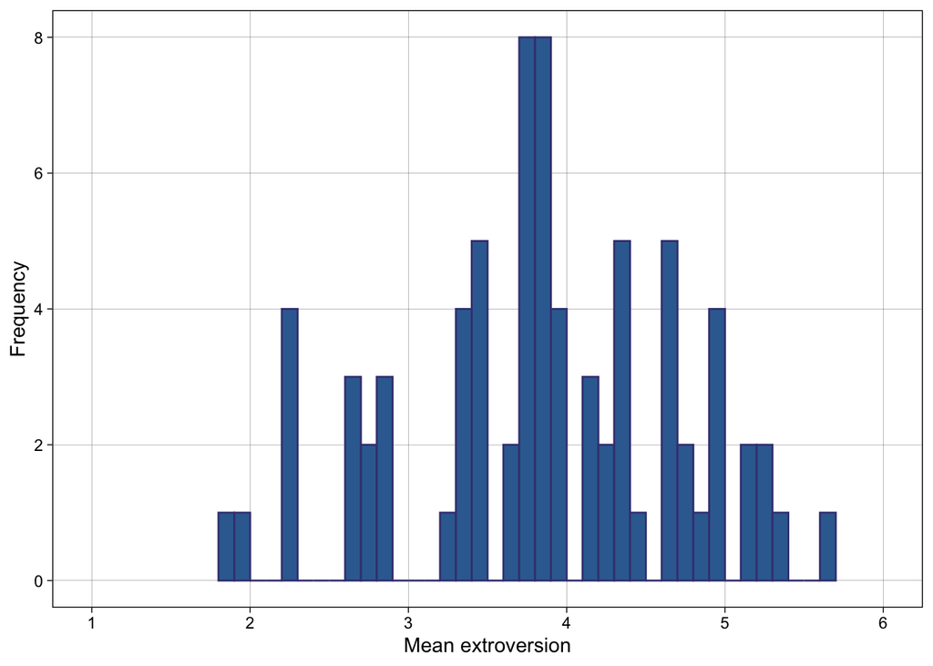

```r
ggplot(data_processed_after_exclusions, aes(x = mean_extroversion)) +
  geom_histogram(binwidth = 0.1,
                 boundary = 0,
                 fill = viridis_pal(begin = 0.45, option = "mako")(1),
                 color = viridis_pal(begin = 0.30, option = "mako")(1)) +
  xlab("Mean extroversion") +
  ylab("Frequency") +
  theme_linedraw() +
  scale_x_continuous(breaks = pretty_breaks(n = 6)) +
  coord_cartesian(xlim = c(1, 6)) +
  theme(panel.grid.minor = element_blank())
```

### Distribution of scores: Agreeableness scale

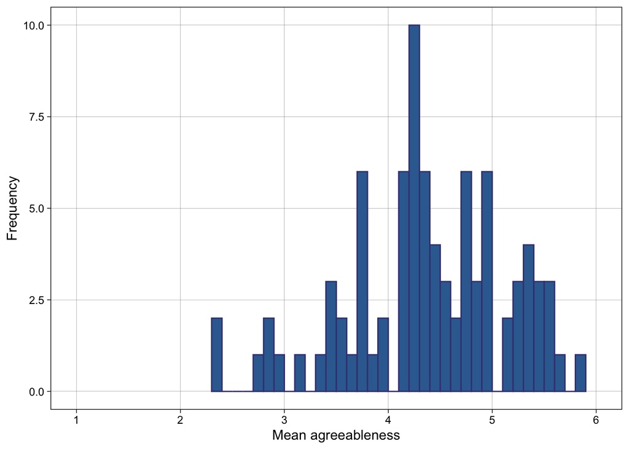

```r
ggplot(data_processed_after_exclusions, aes(x = mean_agreeableness)) +
  geom_histogram(binwidth = 0.1,
                 boundary = 0,
                 fill = viridis_pal(begin = 0.45, option = "mako")(1),
                 color = viridis_pal(begin = 0.30, option = "mako")(1)) +
  xlab("Mean agreeableness") +
  ylab("Frequency") +
  theme_linedraw() +
  scale_x_continuous(breaks = pretty_breaks(n = 6)) +
  coord_cartesian(xlim = c(1, 6)) +
  theme(panel.grid.minor = element_blank())
```

### Distribution of scores: Openness scale

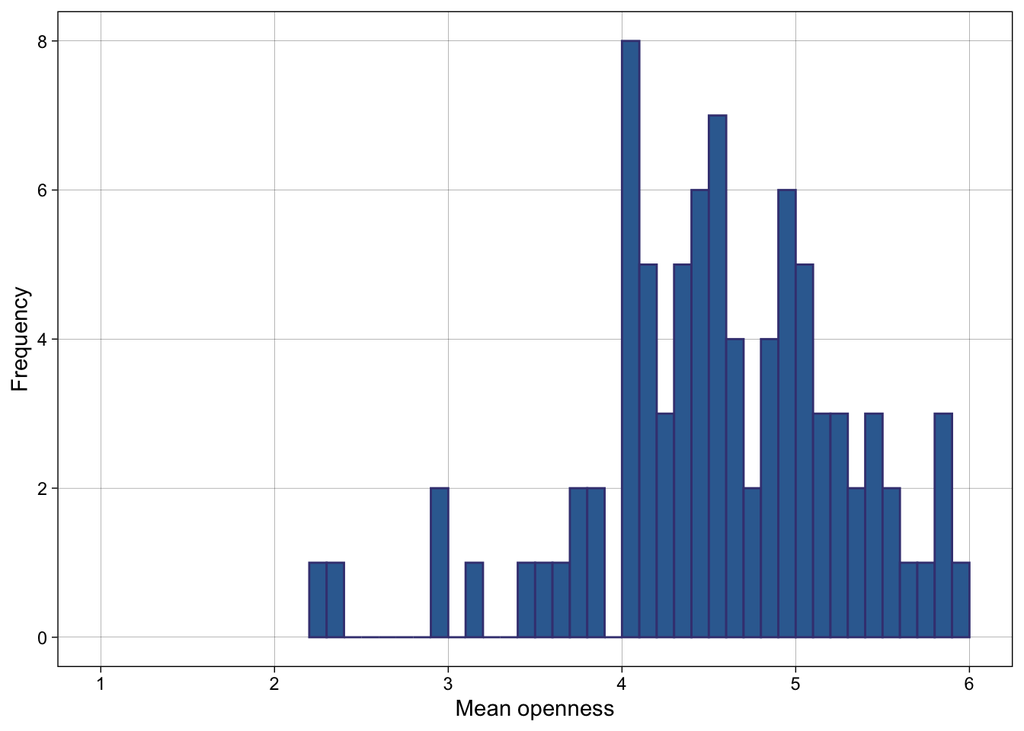

```r
ggplot(data_processed_after_exclusions, aes(x = mean_openness)) +
  geom_histogram(binwidth = 0.1,
                 boundary = 0,
                 fill = viridis_pal(begin = 0.45, option = "mako")(1),
                 color = viridis_pal(begin = 0.30, option = "mako")(1)) +
  xlab("Mean openness") +
  ylab("Frequency") +
  theme_linedraw() +
  scale_x_continuous(breaks = pretty_breaks(n = 6)) +
  coord_cartesian(xlim = c(1, 6)) +
  theme(panel.grid.minor = element_blank())
```

### Distribution of scores: Conscientiousness scale

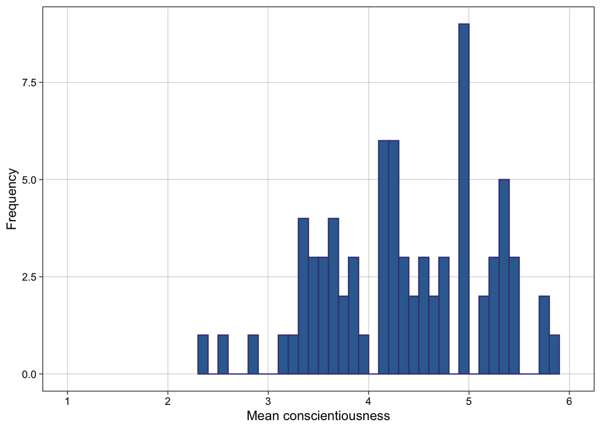

```r
ggplot(data_processed_after_exclusions, aes(x = mean_conscientiousness)) +
  geom_histogram(binwidth = 0.1,
                 boundary = 0,
                 fill = viridis_pal(begin = 0.45, option = "mako")(1),
                 color = viridis_pal(begin = 0.30, option = "mako")(1)) +
  xlab("Mean conscientiousness") +
  ylab("Frequency") +
  theme_linedraw() +
  scale_x_continuous(breaks = pretty_breaks(n = 6)) +
  coord_cartesian(xlim = c(1, 6)) +
  theme(panel.grid.minor = element_blank())
```

### Distribution of scores: Neuroticism scale

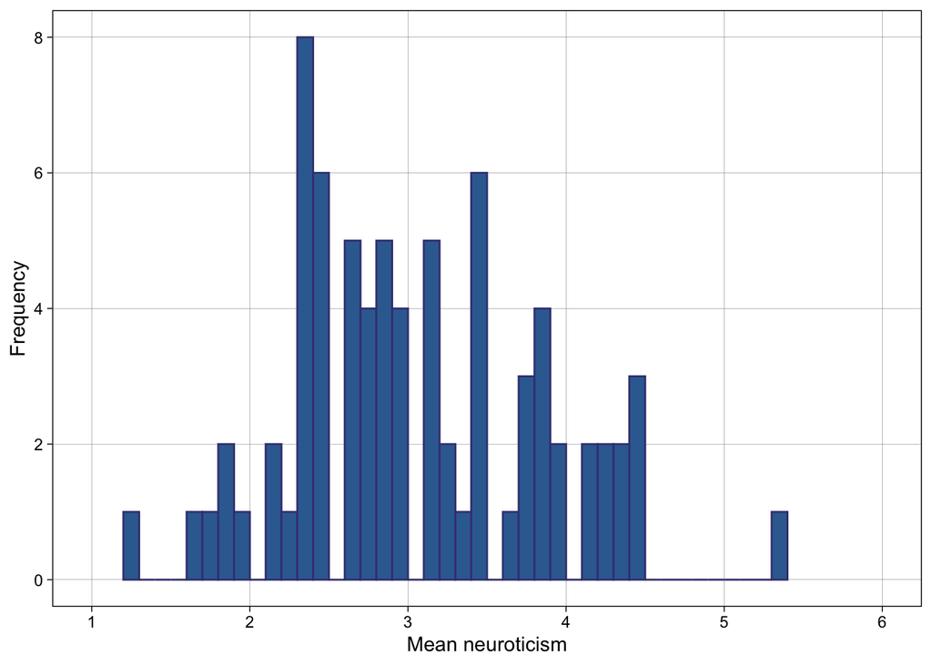

```r
ggplot(data_processed_after_exclusions, aes(x = mean_neuroticism)) +
  geom_histogram(binwidth = 0.1,
                 boundary = 0,
                 fill = viridis_pal(begin = 0.45, option = "mako")(1),
                 color = viridis_pal(begin = 0.30, option = "mako")(1)) +
  xlab("Mean neuroticism") +
  ylab("Frequency") +
  theme_linedraw() +
  scale_x_continuous(breaks = pretty_breaks(n = 6)) +
  coord_cartesian(xlim = c(1, 6)) +
  theme(panel.grid.minor = element_blank())
```

## Distribution of scores on the IAT

The distribution of the participants’ D score on the IAT is shown below in the form of a histograms. The D score can range between -2 and +2.

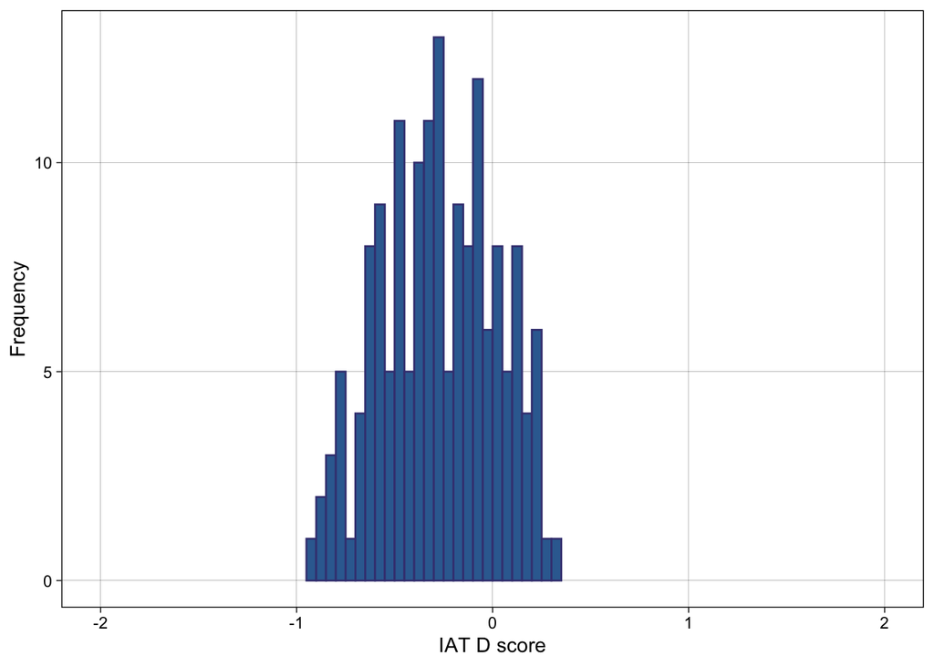

```r
ggplot(data_processed_after_exclusions, aes(x = D)) +
  geom_histogram(binwidth = 0.05,
                 boundary = 0,
                 fill = viridis_pal(begin = 0.45, option = "mako")(1),
                 color = viridis_pal(begin = 0.30, option = "mako")(1)) +
  xlab("IAT D score") +
  ylab("Frequency") +
  theme_linedraw() +
  scale_x_continuous(breaks = pretty_breaks(n = 5)) +
  coord_cartesian(xlim = c(-2, 2)) +
  theme(panel.grid.minor = element_blank())
```

# Correlation IAT and BFI sub-scales

To test if personality traits are correlated with implicit racial stereotypes, a correlation matrix of the Pearson’s r correlations between the IAT and the BFI sub-scales is created. The Pearson correlation coefficient (r) is a statistic that determines how closely two variables are related. Its value ranges from -1 to +1, with 0 denoting no linear correlation, -1 denoting a perfect negative linear correlation, and +1 denoting a perfect positive linear correlation. A correlation between variables means that as one variable’s value changes, the other tends to change in the same way.

```r
correlation_IAT_BFI <- data_processed_after_exclusions %>%
  select(mean_extroversion, mean_agreeableness, mean_openness, mean_conscientiousness, mean_neuroticism) %>%
  sapply(function(x) cor(data_processed_after_exclusions$D, x, use = "complete.obs")) %>%
  round(2) %>%
  as.data.frame() %>%
  t() %>%
  `rownames<-`(., c("D")) %>%
  t() %>%
  kable(caption = "Pearson's r Correlations Between D and BFI Subscales")

correlation_IAT_BFI
```

Pearson’s r Correlations Between D and BFI Subscales

|  | D |
| --- | --- |
| mean_extroversion | 0.10 |
| mean_agreeableness | -0.05 |
| mean_openness | -0.01 |
| mean_conscientiousness | -0.07 |
| mean_neuroticism | 0.07 |

# Hypothesis 1: Scores on the IAT differ between men and women

To test the hypothesis that men and women differ on their scores on the IAT, a t-test is run.

```r
# Filter men and women
data_processed_after_exclusions_H1 <- data_processed_after_exclusions %>%
  filter(gender != "other/missing/error")


report(t.test(data_processed_after_exclusions_H1$D ~ data_processed_after_exclusions_H1$gender,
       var.equal = TRUE,
       alternative = "two.sided"))
```

```
## Effect sizes were labelled following Cohen's (1988) recommendations.
##
## The Two Sample t-test testing the difference of
## data_processed_after_exclusions_H1$D by
## data_processed_after_exclusions_H1$gender (mean in group f = -0.25, mean in
## group m = -0.28) suggests that the effect is positive, statistically not
## significant, and very small (difference = 0.04, 95% CI [-0.06, 0.14], t(137) =
## 0.77, p = 0.443; Cohen's d = 0.13, 95% CI [-0.21, 0.48])
```

**Interpretation:**

The t-test consists of the following two hypothesis:

- **Null hypothesis (H0):** The means for the two populations are equal.
- **Alternative hypothesis (H1) :** The means for the two populations are not equal.

As the p-value (0.443) is greater than our specified significance level (0.05), we can’t reject the null hypothesis. This means that the difference between the two means is not statistically significant. The sample does not provide strong enough evidence to conclude that the two population means are not equal. Men and women do not differ statistically significant in their mean IAT score. This is further shown in the fact that the 95% confidence interval does contain 0. The mean IAT score of women (-0.25) is not significantly higher than the mean IAT score of men (-0.28).

# Hypothesis 2: BFI sub-scales each predict IAT scores

## Statistical regressions

A series of regressions are run to test the hypothesis that each BFI sub-scale predicts IAT scores.

### Regression: IAT and Extroversion scale

```r
regression_IAT_extroversion <- lm(D ~ mean_extroversion, data = data_processed_after_exclusions)

report(regression_IAT_extroversion)
```

```
## We fitted a linear model (estimated using OLS) to predict D with
## mean_extroversion (formula: D ~ mean_extroversion). The model explains a
## statistically not significant and very weak proportion of variance (R2 = 0.01,
## F(1, 73) = 0.77, p = 0.383, adj. R2 = -3.11e-03). The model's intercept,
## corresponding to mean_extroversion = 0, is at -0.41 (95% CI [-0.71, -0.11],
## t(73) = -2.71, p = 0.008). Within this model:
##
##   - The effect of mean extroversion is statistically non-significant and positive
## (beta = 0.03, 95% CI [-0.04, 0.11], t(73) = 0.88, p = 0.383; Std. beta = 0.10,
## 95% CI [-0.13, 0.33])
##
## Standardized parameters were obtained by fitting the model on a standardized
## version of the dataset. 95% Confidence Intervals (CIs) and p-values were
## computed using a Wald t-distribution approximation.
```

### Regression: IAT and Agreeableness scale

```r
regression_IAT_agreeableness <- lm(D ~ mean_agreeableness, data = data_processed_after_exclusions)

report(regression_IAT_agreeableness)
```

```
## We fitted a linear model (estimated using OLS) to predict D with
## mean_agreeableness (formula: D ~ mean_agreeableness). The model explains a
## statistically not significant and very weak proportion of variance (R2 =
## 2.63e-03, F(1, 84) = 0.22, p = 0.639, adj. R2 = -9.25e-03). The model's
## intercept, corresponding to mean_agreeableness = 0, is at -0.18 (95% CI [-0.55,
## 0.19], t(84) = -0.96, p = 0.340). Within this model:
##
##   - The effect of mean agreeableness is statistically non-significant and
## negative (beta = -0.02, 95% CI [-0.10, 0.06], t(84) = -0.47, p = 0.639; Std.
## beta = -0.05, 95% CI [-0.27, 0.17])
##
## Standardized parameters were obtained by fitting the model on a standardized
## version of the dataset. 95% Confidence Intervals (CIs) and p-values were
## computed using a Wald t-distribution approximation.
```

### Regression: IAT and Openness scale

```r
regression_IAT_openness <- lm(D ~ mean_openness, data = data_processed_after_exclusions)

report(regression_IAT_openness)
```

```
## We fitted a linear model (estimated using OLS) to predict D with mean_openness
## (formula: D ~ mean_openness). The model explains a statistically not
## significant and very weak proportion of variance (R2 = 1.16e-04, F(1, 84) =
## 9.77e-03, p = 0.921, adj. R2 = -0.01). The model's intercept, corresponding to
## mean_openness = 0, is at -0.25 (95% CI [-0.65, 0.16], t(84) = -1.20, p =
## 0.234). Within this model:
##
##   - The effect of mean openness is statistically non-significant and negative
## (beta = -4.35e-03, 95% CI [-0.09, 0.08], t(84) = -0.10, p = 0.921; Std. beta =
## -0.01, 95% CI [-0.23, 0.21])
##
## Standardized parameters were obtained by fitting the model on a standardized
## version of the dataset. 95% Confidence Intervals (CIs) and p-values were
## computed using a Wald t-distribution approximation.
```

### Regression: IAT and Conscientiousness scale

```r
regression_IAT_conscientiousness <- lm(D ~ mean_conscientiousness, data = data_processed_after_exclusions)

report(regression_IAT_conscientiousness)
```

```
## We fitted a linear model (estimated using OLS) to predict D with
## mean_conscientiousness (formula: D ~ mean_conscientiousness). The model
## explains a statistically not significant and very weak proportion of variance
## (R2 = 4.53e-03, F(1, 73) = 0.33, p = 0.566, adj. R2 = -9.11e-03). The model's
## intercept, corresponding to mean_conscientiousness = 0, is at -0.18 (95% CI
## [-0.54, 0.19], t(73) = -0.96, p = 0.338). Within this model:
##
##   - The effect of mean conscientiousness is statistically non-significant and
## negative (beta = -0.02, 95% CI [-0.11, 0.06], t(73) = -0.58, p = 0.566; Std.
## beta = -0.07, 95% CI [-0.30, 0.17])
##
## Standardized parameters were obtained by fitting the model on a standardized
## version of the dataset. 95% Confidence Intervals (CIs) and p-values were
## computed using a Wald t-distribution approximation.
```

### Regression: IAT and Neuroticism scale

```r
regression_IAT_neuroticism <- lm(D ~ mean_neuroticism, data = data_processed_after_exclusions)

report(regression_IAT_neuroticism)
```

```
## We fitted a linear model (estimated using OLS) to predict D with
## mean_neuroticism (formula: D ~ mean_neuroticism). The model explains a
## statistically not significant and very weak proportion of variance (R2 =
## 5.08e-03, F(1, 73) = 0.37, p = 0.544, adj. R2 = -8.55e-03). The model's
## intercept, corresponding to mean_neuroticism = 0, is at -0.36 (95% CI [-0.62,
## -0.10], t(73) = -2.74, p = 0.008). Within this model:
##
##   - The effect of mean neuroticism is statistically non-significant and positive
## (beta = 0.03, 95% CI [-0.06, 0.11], t(73) = 0.61, p = 0.544; Std. beta = 0.07,
## 95% CI [-0.16, 0.30])
##
## Standardized parameters were obtained by fitting the model on a standardized
## version of the dataset. 95% Confidence Intervals (CIs) and p-values were
## computed using a Wald t-distribution approximation.
```

## Scatter plots

A series of scatter plots are created to show how the BFI sub-scale scores predict IAT scores including regression lines.

### Plot: IAT and Extroversion scale

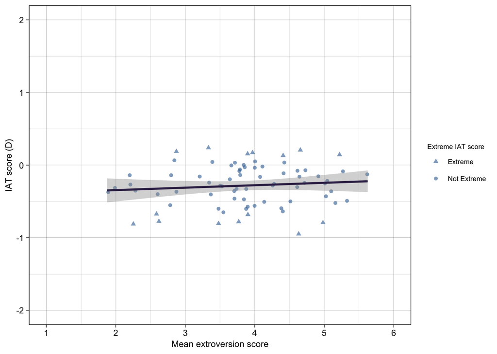

```r
# New column to identify extreme scores
data_processed_after_exclusions_H2 <- data_processed_after_exclusions %>%
  mutate(extreme_IAT = ifelse(D > quantile(D, 0.9) | D < quantile(D, 0.1), "Extreme", "Not Extreme"))


# IAT score as dependent variable
plot_IAT_extroversion <- ggplot(data_processed_after_exclusions_H2,
       aes(y = D,
           x = mean_extroversion)) +
  geom_jitter(aes(shape = extreme_IAT),
              color = viridis_pal(begin = 0.45, option = "mako")(1),
              alpha = 0.6) +
  geom_smooth(method = "lm",
              color = viridis_pal(begin = 0.2, option = "mako")(1)) +
  scale_y_continuous(name = "IAT score (D)",
                     breaks = seq(-2, 2, 1),
                     limits = c(-2, 2)) +
  scale_x_continuous(name = "Mean extroversion score",
                     breaks = seq(1, 6, 1),
                     limits = c(1, 6)) +
  scale_shape_manual(values = c(17, 16),
                     name = "Extreme IAT score",
                     labels = c("Extreme", "Not Extreme")) +
  theme_linedraw() +
  theme(axis.title.x = element_text(size = 9),
        axis.title.y = element_text(size = 9),
        legend.title = element_text(size = 7),
        legend.text = element_text(size = 7))

plot_IAT_extroversion
```

### Plot: IAT and Agreeableness scale

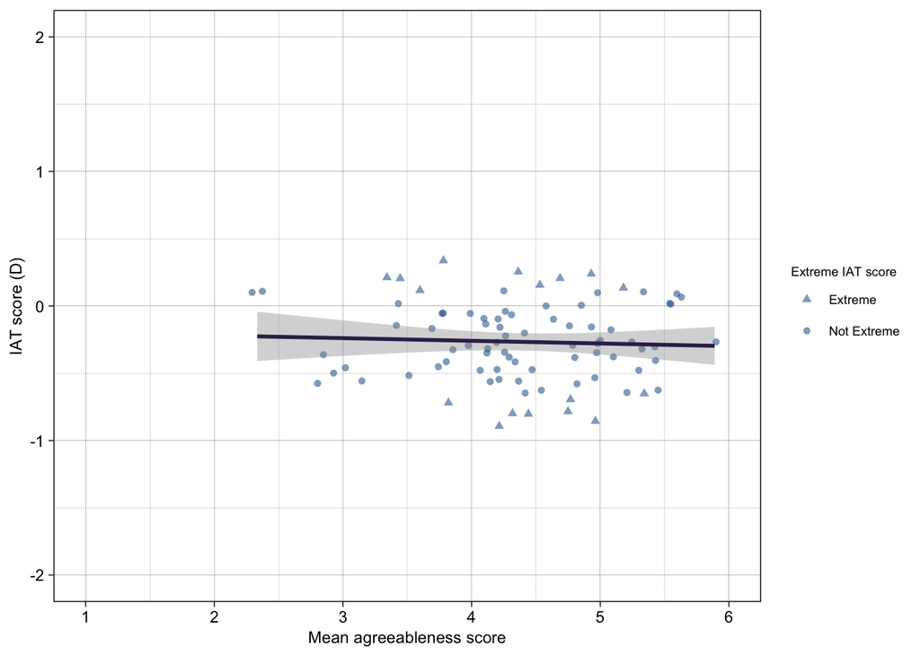

```r
# IAT score as dependent variable
plot_IAT_agreeableness <- ggplot(data_processed_after_exclusions_H2,
       aes(y = D,
           x = mean_agreeableness)) +
  geom_jitter(aes(shape = extreme_IAT),
              color = viridis_pal(begin = 0.45, option = "mako")(1),
              alpha = 0.6) +
  geom_smooth(method = "lm",
              color = viridis_pal(begin = 0.2, option = "mako")(1)) +
  scale_y_continuous(name = "IAT score (D)",
                     breaks = seq(-2, 2, 1),
                     limits = c(-2, 2)) +
  scale_x_continuous(name = "Mean agreeableness score",
                     breaks = seq(1, 6, 1),
                     limits = c(1, 6)) +
  scale_shape_manual(values = c(17, 16),
                     name = "Extreme IAT score",
                     labels = c("Extreme", "Not Extreme")) +
  theme_linedraw() +
  theme(axis.title.x = element_text(size = 9),
        axis.title.y = element_text(size = 9),
        legend.title = element_text(size = 7),
        legend.text = element_text(size = 7))

plot_IAT_agreeableness
```

### Plot: IAT and Openness scale

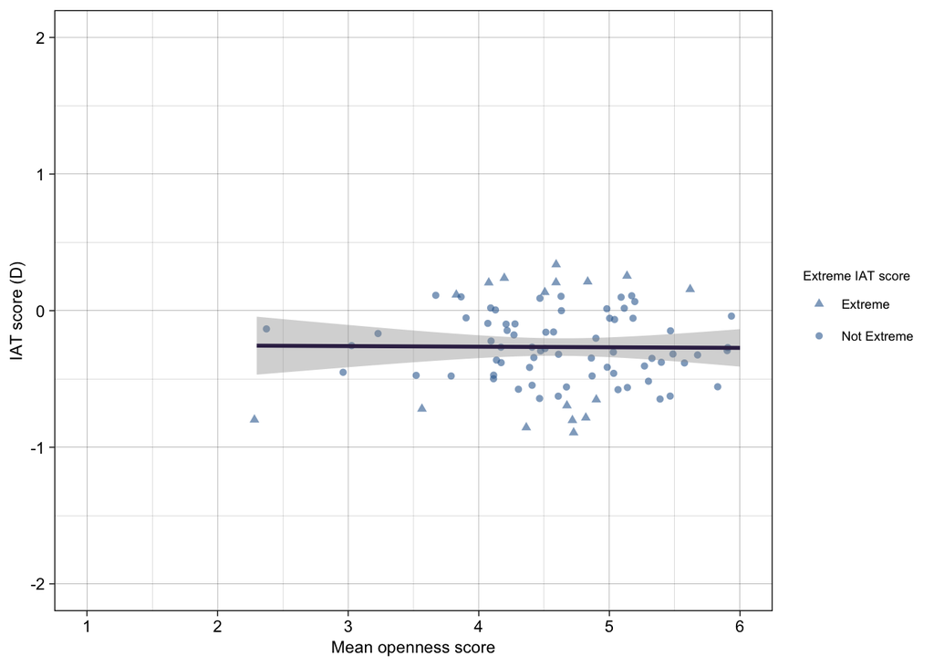

```r
# IAT score as dependent variable
plot_IAT_openness <- ggplot(data_processed_after_exclusions_H2,
       aes(y = D,
           x = mean_openness)) +
  geom_jitter(aes(shape = extreme_IAT),
              color = viridis_pal(begin = 0.45, option = "mako")(1),
              alpha = 0.6) +
  geom_smooth(method = "lm",
              color = viridis_pal(begin = 0.2, option = "mako")(1)) +
  scale_y_continuous(name = "IAT score (D)",
                     breaks = seq(-2, 2, 1),
                     limits = c(-2, 2)) +
  scale_x_continuous(name = "Mean openness score",
                     breaks = seq(1, 6, 1),
                     limits = c(1, 6)) +
  scale_shape_manual(values = c(17, 16),
                     name = "Extreme IAT score",
                     labels = c("Extreme", "Not Extreme")) +
  theme_linedraw() +
  theme(axis.title.x = element_text(size = 9),
        axis.title.y = element_text(size = 9),
        legend.title = element_text(size = 7),
        legend.text = element_text(size = 7))

plot_IAT_openness
```

### Plot: IAT and Conscientiousness scale

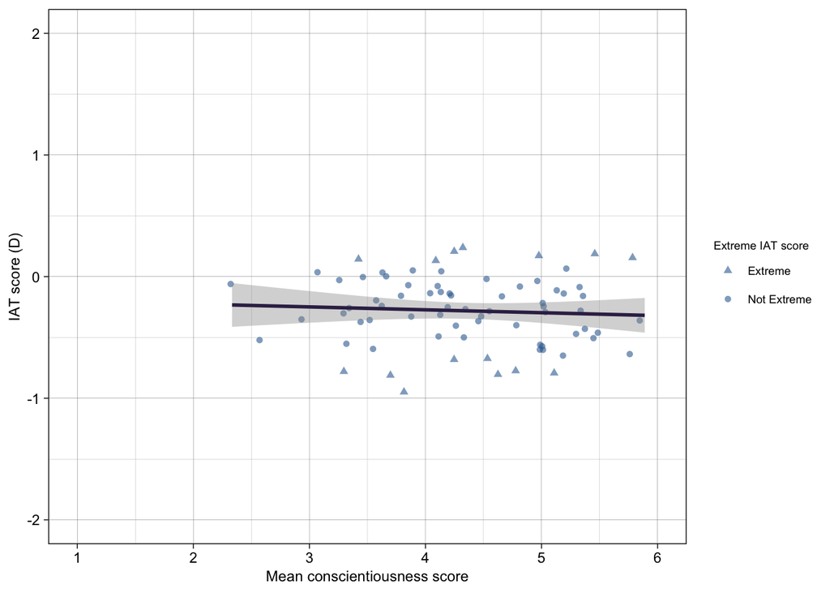

```r
# IAT score as dependent variable
plot_IAT_conscientiousness <- ggplot(data_processed_after_exclusions_H2,
       aes(y = D,
           x = mean_conscientiousness)) +
  geom_jitter(aes(shape = extreme_IAT),
              color = viridis_pal(begin = 0.45, option = "mako")(1),
              alpha = 0.6) +
  geom_smooth(method = "lm",
              color = viridis_pal(begin = 0.2, option = "mako")(1)) +
  scale_y_continuous(name = "IAT score (D)",
                     breaks = seq(-2, 2, 1),
                     limits = c(-2, 2)) +
  scale_x_continuous(name = "Mean conscientiousness score",
                     breaks = seq(1, 6, 1),
                     limits = c(1, 6)) +
  scale_shape_manual(values = c(17, 16),
                     name = "Extreme IAT score",
                     labels = c("Extreme", "Not Extreme")) +
  theme_linedraw() +
  theme(axis.title.x = element_text(size = 9),
        axis.title.y = element_text(size = 9),
        legend.title = element_text(size = 7),
        legend.text = element_text(size = 7))

plot_IAT_conscientiousness
```

### Plot: IAT and Neuroticism scale

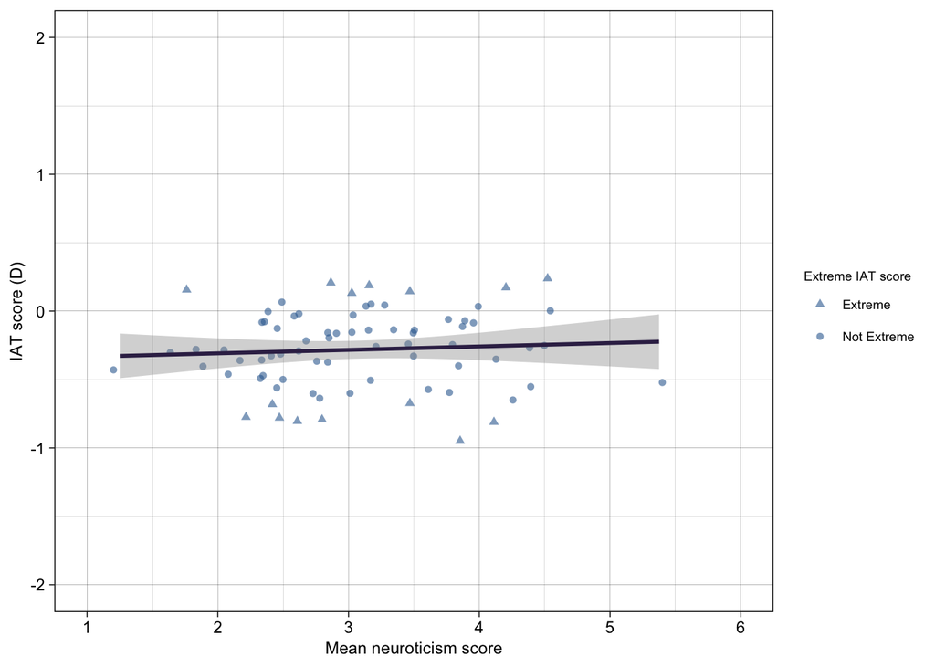

```r
# IAT score as dependent variable
plot_IAT_neuroticism <- ggplot(data_processed_after_exclusions_H2,
       aes(y = D,
           x = mean_neuroticism)) +
  geom_jitter(aes(shape = extreme_IAT),
              color = viridis_pal(begin = 0.45, option = "mako")(1),
              alpha = 0.6) +
  geom_smooth(method = "lm",
              color = viridis_pal(begin = 0.2, option = "mako")(1)) +
  scale_y_continuous(name = "IAT score (D)",
                     breaks = seq(-2, 2, 1),
                     limits = c(-2, 2)) +
  scale_x_continuous(name = "Mean neuroticism score",
                     breaks = seq(1, 6, 1),
                     limits = c(1, 6)) +
  scale_shape_manual(values = c(17, 16),
                     name = "Extreme IAT score",
                     labels = c("Extreme", "Not Extreme")) +
  theme_linedraw() +
  theme(axis.title.x = element_text(size = 9),
        axis.title.y = element_text(size = 9),
        legend.title = element_text(size = 7),
        legend.text = element_text(size = 7))

plot_IAT_neuroticism
```

### Combined plot

These separate scatter plots are combined into a single ggplot object.

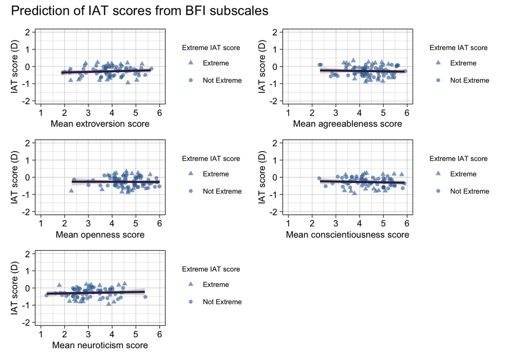

```r
combined_plot_IAT_BFI <- plot_IAT_extroversion + plot_IAT_agreeableness + plot_IAT_openness + plot_IAT_conscientiousness + plot_IAT_neuroticism + plot_layout(ncol = 2) + plot_annotation(title = "Prediction of IAT scores from BFI subscales")

combined_plot_IAT_BFI
```

#### Saving plot

Saving of the combined ggplot object to disk as .pdf and .png in the “communications” folder.

```r
ggsave(filename = "combined_plot_IAT_BFI.pdf", plot = combined_plot_IAT_BFI, path = "../communications")
ggsave(filename = "combined_plot_IAT_BFI.png", plot = combined_plot_IAT_BFI, path = "../communications")
```